# PDF를 데이터로 보는 올바른 자세

광학문자인식(OCR, Optical Character Recognition)

이광춘

[Tidyverse Korea](https://www.facebook.com/groups/tidyverse/)

2021-05-24

[figure not shown]

# 1 OCR이란?

**광학문자인식** (OCR, Optical Character Recognition)은 이미지 혹은 사진 속에 담긴 텍스트를 기계가 읽을 수 있는 형태(Machine-Readable Format)로 변환시켜 텍스트를 선택, 편집, 검색 가능하게 만드는 일련의 작업을 지칭한다.

# 2 OCR 응용분야

OCR 응용분야로 다음을 들 수 있다.

- 인보이스 데이터 자동 입력: 인보이스와 같은 (반)정형 문서에 포함된 텍스트를 OCR로 읽어 정형데이터를 추출한다.
- 여권 MRZ 추출: 여권과 같은 증명서에서 MRC (Machine Readable Zone) 영역에서 텍스트를 추출하여 대사작업에 활용한다.
- 차량번호판 인식: 주차차량 관리 및 주차요금 정산을 위한 차량 번호판 인식
- 교통 표시판 인식: 자율주행차가 교통법규 준수를 위한 다양한 교통 표시판 인식
- 고문서 스캔: 절판되거나 도서관에 보관된 책을 스캔하여 검색 및 자연어 처리 업무를 위한 OCR 작업
- 시각 장애인: OCR 기술을 사용해서 추출된 텍스트 데이터를 TTS(Text-to-Speech)를 사용해서 시각장애인의 정보 접근성을 높일 수 있다.

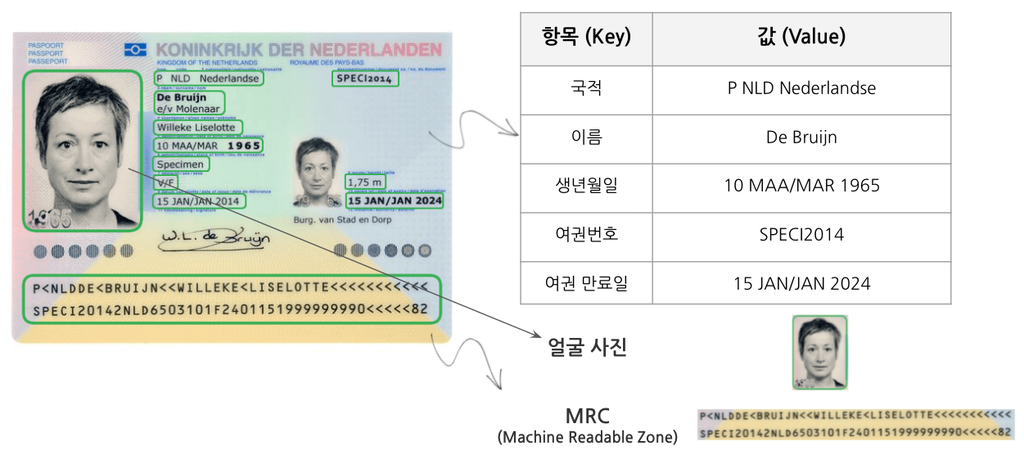

# 3 OCR 작업흐름

OCR 작업흐름은 텍스트가 담긴 이미지를 바로 OCR 작업을 돌릴 경우 정확도가 떨어지기 때문에 이미지 전처리 작업(회전, 노이즈 제거 등)을 수행하고 텍스트 추출작업을 수행한다. 그리고 나서 추출된 텍스트를 후처리 작업을 통해서 재구조화시키고 나서 텍스트를 저장하는 과정을 거치게 된다.

[figure not shown]

데이터 과학자 [이광춘](https://github.com/statkclee/) 저작

*kwangchun.lee.7@gmail.com*